# Study 1 Analysis

```r
knitr::opts_chunk$set(echo=TRUE, message=FALSE, warning=FALSE)
library(Hmisc) # summarize namespace overlaps with dplyr
library(here)
library(tidyverse)
library(GGally) # Corregiogram
library(corrr)
library(kableExtra)
library(lme4)
library(lmerTest) # p-values
source(here("r", "ggcorr.R")) # I customized ggcorr to not to replace the spaces in variable names with undersocres
library(forestplot)
library(broom)
library(broom.mixed)
library(apastats) # Formatting stats in to APA
library(ggpubr)
library(ggtext)
source(here("r", "namifunc.R"))
# Facet nested
# devtools::install_github("teunbrand/ggh4x")

# Load Datasets  ---------------------------------------------------------------
# S1a
Study1a <- rio::import(here("data_public/Study1a_public.rds"))
# S1b
S1b_data <- rio::import(here("data_public/Study1b_public.rds"))
# S1c
S1c_data <- rio::import(here("data_public/Study1c_public.rds"))
# S1d
S1d_data <- rio::import(here("data_public/Study1d_public.rds"))
# S1e
S1e_data <- rio::import(here("data_public/Study1e_public.rds"))
```

# 1 Study 1a (RPR Data)

## 1.1 Participants

All undergraduate students enrolled in an introductory psychology course were invited to complete a mass testing session for the psychology participant pool at the University of Delaware in 2018 Fall. Among those who accessed the survey website (1160 participants), 571 participants were randomly assigned to a questionnaire block that contained the Heart Manikin and thus included in this study.

## 1.2 Procedure and Materials

(In the main text)

## 1.3 Results

```r
Study1a_target_vars <- Study1a %>%
  select(heart, valence, CESD_sum, social_isolation_mean, bio_diff_mean,
         reactivity_mean, self_monitoring_sum, paradoxical_mindset_mean,
         integrative_complexity_mean,
         multiple_identitiy_mean) %>%
  rename("Heart" = heart,
         "Valence" = valence,
         "CESD" = CESD_sum,
         "Isolation" = social_isolation_mean,
         "Biological Beliefs" = bio_diff_mean,
         "Reactivity" = reactivity_mean,
         "Monitoring" = self_monitoring_sum,
         "Paradox" = paradoxical_mindset_mean,
         "Complexity" = integrative_complexity_mean,
         "Multiple Identity" = multiple_identitiy_mean)
# Export Taget Variable DF for the plots in Appendix
write_rds(Study1a_target_vars, here("data_public/subset", "Study1a_public_target.rds"))
write_csv(Study1a_target_vars, here("data_public/subset", "Study1a_public_target.csv"))
# Assign variable types
S1a_var_types <- c(valence = "Convergent",
                   CESD_sum = "Convergent (R)",
                   social_isolation_mean = "Convergent (R)",
                   bio_diff_mean = "Discriminant",
                   reactivity_mean = "Discriminant",
                   self_monitoring_sum = "Discriminant",
                   paradoxical_mindset_mean = "Discriminant",
                   integrative_complexity_mean = "Discriminant",
                   multiple_identitiy_mean = "Discriminant")
# Create a named vector of variable names (long) and their types
S1a_var_types_long <- S1a_var_types
names(S1a_var_types_long) <- names(Study1a_target_vars)[-1]

# Calculate correlations via the ad-hoc get_correlations()
S1a_cor_CIs <- Study1a_target_vars %>%
  get_correlations(vars = 2:last_col(),
                   outcome = Heart)
## Add Types
S1a_cor_CIs <- S1a_cor_CIs %>%
  mutate(type = S1a_var_types_long[label])
## Add outcome for later merging (Only Heart T1)
S1a_cor_CIs <- S1a_cor_CIs %>%
  mutate(outcome = "Heart T1")

# Data Table
# Markdown-formatted APA Text (95% only)
s1a_txt <- S1a_cor_CIs %>% select(label, APA_model95) %>%
  # `deframe()` to convert two-column df to a named vector
  deframe() %>% as.list()
```

To test convergent and discriminant validities, I examined bivariate correlations between the Heart Manikin scores and the scores of the measures in Table 1. Results are presented in Figure 1.1 (see Appendix for the bivariate correlation table). Consistent with the prediction, the Heart Manikin scores correlated with the hypothesized measures for convergent validity: the Valence Manikin (*r*(569) = 0.71, *p* < .001), social isolation (*r*(564) = -0.60, *p* < .001), CESD (*r*(569) = -0.58, *p* < .001). For the discriminant validity, results are mixed. As predicted, the Heart Manikin scores did not significantly correlate with measures of interpersonal reactivity (*r*(567) = 0.01, *p* = .856), paradoxical mindset (*r*(567) = 0.03, *p* = .451), or integrative complexity (*r*(566) = 0.02, *p* = .596). The 90% confidence intervals fell within the smallest effect size of equivalence, and thus they are considered as theoretically equivalent to zero. Contrary to the prediction, the heart manikin scores were significantly related to the measures of multiple identity (*r*(566) = 0.19, *p* < .001), social monitoring (*r*(568) = -0.09, *p* = .040), and beliefs in biological differences between Black and White people (*r*(568) = -0.11, *p* = .008). Note that the 90% confidence interval for the correlation between the Heart Manikin scores and the social monitoring scores fell within the SEOSI, and thus the relationship can be considered as theoretically equivalent to zero even though the estimate may be different from zero. Overall, these results suggest strong support for the convergent validity and moderate support for the discriminant validity of the Heart Manikin.

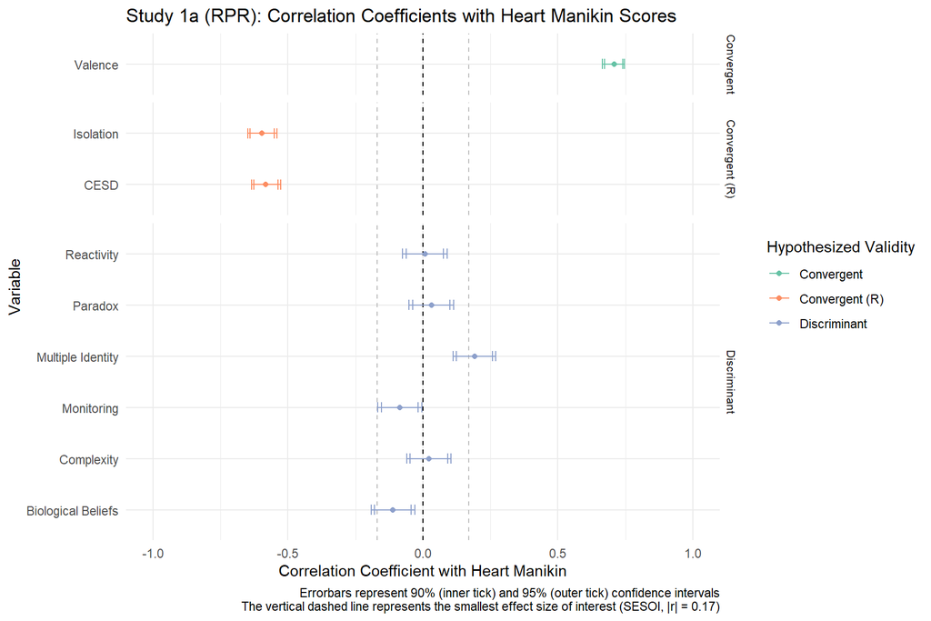

Figure 1.1: Study 1a - Forestplot Showing Correlation Coefficients with Heart Manikin Scores

```r
## Forest Plot
s1a_forest <- S1a_cor_CIs %>%
  ggplot(aes(y = label, x = estimate, color = type)) +
  # Zero and SESOI
  geom_zeroSESOI +
  # Data points
  geom_point()+
  # CI error bars - 90%
  geom_errorbarh(aes(xmin = conf.low_model90, xmax = conf.high_model90), height = .2) +
  # CI error bars - 95%
  geom_errorbarh(aes(xmin = conf.low_model95, xmax = conf.high_model95), height = .2) +
  # x-axis limits
  scale_x_continuous(limits=c(-1,1), name='Correlation Coefficient with Heart Manikin')+
  # y-axis label
  ylab('Variable') +
  # Facet by Validity Type
  facet_grid(type~., scales= "free", space= "free") +
  # Title
  ggtitle("Study 1a (RPR): Correlation Coefficients with Heart Manikin Scores") +
  # Change the font size on strip text (Validity Labels)
  theme(strip.text.y = element_text(size = 8)) +
  # Caption
  labs(caption = paste(sep = "\n",
                       "Errorbars represent 90% (inner tick) and 95% (outer tick) confidence intervals",
                       sprintf("The vertical dashed line represents the smallest effect size of interest (SESOI, |r| = %s)", SESOI_r))) +
  scale_color_brewer(name = "Hypothesized Validity", palette = "Set2")

s1a_forest
```

# 2 Study 1b (RAIv1)

## 2.1 Participants

```r
# Get the participants who participanted more than twice in one visit
S1b_duplicates <- S1b_data %>%
  group_by(id, visit) %>%
  summarise(n = n()) %>% filter(n > 1)
S1b_duplicates <- S1b_data %>%
  group_by(id, visit) %>%
  summarise(n = n()) %>% filter(id %in% S1b_duplicates$id)
#  S1b_data %>% filter(id == 306)
#  S1b_data %>% filter(id == 402)
# Print out the different dates, if needed
# S1b_data %>% filter(id %in% S1b_duplicates$id) %>% select(id, visit, StartDate) %>% arrange(id, visit)
S1b_data <- S1b_data %>%
  # p 306, only include the first data point
  filter(!(id == 306 & StartDate == lubridate::as_datetime("2016-11-18 11:34:00"))) %>%
  filter(!(id == 402 & StartDate == lubridate::as_datetime("2016-09-22 12:31:00")))
# filter(id == 306 | id == 402)
s1b_dates <- S1b_data %>% pivot_wider(id, names_prefix = "visit", names_from = visit, values_from = StartDate) %>%
  mutate(gap12 = visit2 - visit1,
         gap13 = visit3 - visit1,
         gap23 = visit3 - visit2)
s1b_dates_summary <- s1b_dates %>%
  summarise(across(c("gap12", "gap13", "gap23"),
                   .fns = list("mean" = ~mean(., na.rm = T) %>% round(2)))) %>%
  rowwise() %>%
  mutate(gap_mean = mean(c(gap12_mean, gap13_mean, gap23_mean) %>% round(2)))
```

The dataset contained data from 121 participants. Participants were eligible to participate if they were in a romantic relationship at the beginning of the study. Participants were recruited from the psychology participant pool at the University of Delaware. They received partial course credits as compensation. During the data inspection, I found that two participants had duplicate data points in the study One participant had 2 data points for the Visit 3 on the same date but no data for Visit 2. For this participant, I disregarded their data from later participation on that day. Another participant had participated twice for Visit 1 on different dates. I disregarded their data for the later participation for Visit 1. On average, participants participated Visit 1 and Visit 2 27.24 days apart, and Visit 2 and Visit 3 27.23 days apart.